# Coursework - Data Science I

Malik Sharkawy, 222234988

# Collection / Preparation

First of all we will import the libraries, that we need for our project.

```r
library(data.table)
library(ggplot2)
library(plot3D)
library(viridisLite)
library(FNN)
library(rpart)
library(rpart.plot)
library(viridisLite)
library(ggplot2)
```

Lets read the input of our dataset

```r
dt_happiness <- fread(file = "Datasets/WHR_2024.csv", sep = ",")
```

First of all I will explore the basic structure of the dataset

```r
str(dt_happiness)
```

```
Classes ‘data.table’ and 'data.frame':  143 obs. of  9 variables:
 $ country                     : chr  "Finland" "Denmark" "Iceland" "Sweden" ...
 $ region                      : chr  "Western Europe" "Western Europe" "Western Europe" "Western Europe" ...
 $ happiness_score             : num  7.74 7.58 7.53 7.34 7.34 ...
 $ gdp_per_capita              : num  1.84 1.91 1.88 1.88 1.8 ...
 $ social_support              : num  1.57 1.52 1.62 1.5 1.51 ...
 $ healthy_life_expectancy     : num  0.695 0.699 0.718 0.724 0.74 0.706 0.704 0.708 0.747 0.692 ...
 $ freedom_to_make_life_choices: num  0.859 0.823 0.819 0.838 0.641 0.725 0.835 0.801 0.759 0.756 ...
 $ generosity                  : num  0.142 0.204 0.258 0.221 0.153 0.247 0.224 0.146 0.173 0.225 ...
 $ perceptions_of_corruption   : num  0.546 0.548 0.182 0.524 0.193 0.372 0.484 0.432 0.498 0.323 ...
 - attr(*, ".internal.selfref")=<externalptr>
```

First of all we convert all empty strings to Na, so our omit function can remove rows, where attributes are empty string

```r
dt_happiness[
  dt_happiness$country == ""
  | dt_happiness$region == ""
  | dt_happiness$happiness_score == 0
  | dt_happiness$gdp_per_capita == 0
  | dt_happiness$social_support == 0
  | dt_happiness$healthy_life_expectancy == 0
  | dt_happiness$freedom_to_make_life_choices == 0
  | dt_happiness$generosity == 0
  | dt_happiness$perceptions_of_corruption == 0
] <- NA

dt_happiness <- na.omit(dt_happiness)
```

Lets see the first 6 rows of our dataset.

```r
head(dt_happiness) # First 6 lines
```

| country | region | happiness_score | gdp_per_capita | social_support | healthy_life_expectancy | freedom_to_make_life_choices | generosity | perceptions_of_corruption |
| --- | --- | --- | --- | --- | --- | --- | --- | --- |
| Finland | Western Europe | 7.741 | 1.844 | 1.572 | 0.695 | 0.859 | 0.142 | 0.546 |
| Denmark | Western Europe | 7.583 | 1.908 | 1.520 | 0.699 | 0.823 | 0.204 | 0.548 |
| Iceland | Western Europe | 7.525 | 1.881 | 1.617 | 0.718 | 0.819 | 0.258 | 0.182 |
| Sweden | Western Europe | 7.344 | 1.878 | 1.501 | 0.724 | 0.838 | 0.221 | 0.524 |
| Israel | Middle East and North Africa | 7.341 | 1.803 | 1.513 | 0.740 | 0.641 | 0.153 | 0.193 |
| Netherlands | Western Europe | 7.319 | 1.901 | 1.462 | 0.706 | 0.725 | 0.247 | 0.372 |

Now I will define some reusable functions:

```r
calculate_tree_metrics <- function(model, dataset, key) {
  y_value <- dataset[[key]]
  y_pred <- predict(model, dataset)

  rmse <- sqrt(mean((y_value - y_pred)^2))
  r2 <- 1 - sum((y_value - y_pred)^2) / sum((y_value - mean(y_value))^2)

  list(
    rmse = rmse,
    r2 = r2
  )
}

calculate_lm_metrics <- function(model) {
  rmse <- sqrt(mean(model$residuals^2))
  r2 <- summary(model)$r.squared

  list(
    rmse = rmse,
    r2 = r2
  )
}
```

# Exploration

Lets summarize our data

```r
summary(dt_happiness)
```

```
   country             region          happiness_score gdp_per_capita  social_support
 Length:130         Length:130         Min.   :2.707   Min.   :0.534   Min.   :0.1280
 Class :character   Class :character   1st Qu.:4.804   1st Qu.:1.083   1st Qu.:0.9317
 Mode  :character   Mode  :character   Median :5.819   Median :1.433   Median :1.2400
                                       Mean   :5.600   Mean   :1.400   Mean   :1.1445
                                       3rd Qu.:6.447   3rd Qu.:1.762   3rd Qu.:1.3907
                                       Max.   :7.741   Max.   :2.141   Max.   :1.6170
 healthy_life_expectancy freedom_to_make_life_choices   generosity     perceptions_of_corruption
 Min.   :0.1560          Min.   :0.1720               Min.   :0.0140   Min.   :0.00600
 1st Qu.:0.4042          1st Qu.:0.5383               1st Qu.:0.0960   1st Qu.:0.06725
 Median :0.5595          Median :0.6455               Median :0.1390   Median :0.12150
 Mean   :0.5300          Mean   :0.6293               Mean   :0.1485   Mean   :0.15646
 3rd Qu.:0.6552          3rd Qu.:0.7420               3rd Qu.:0.1933   3rd Qu.:0.19525
 Max.   :0.8570          Max.   :0.8630               Max.   :0.4010   Max.   :0.57500
```

Now we will have a look at the density of the happiness score.

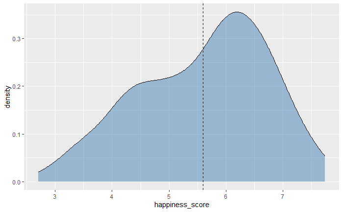

```r
ggplot(dt_happiness, aes(x = happiness_score)) +
  geom_density(fill = "steelblue", alpha = 0.5) +
  geom_vline(xintercept = mean(dt_happiness$happiness_score), linetype="dashed")
```

We can see that the happiness_score of most countries is around 5.7 and 6.5. The vertical dashed-line represents, the mean happiness_score. It is at around 5.5.

The next plot will visualize the distribution of the happiness score depending on the GDP per capita

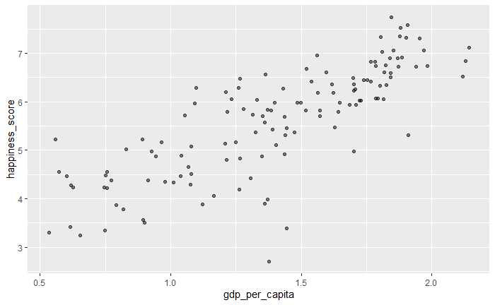

```r
ggplot(dt_happiness, aes(gdp_per_capita, happiness_score)) +
  geom_point(alpha = 0.5)
```

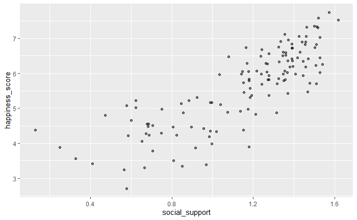

```r
ggplot(dt_happiness, aes(social_support, happiness_score)) +
  geom_point(alpha = 0.5)
```

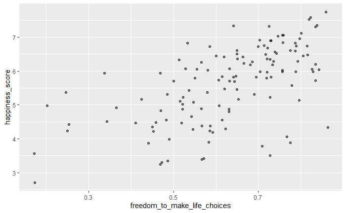

```r
ggplot(dt_happiness, aes(freedom_to_make_life_choices, happiness_score)) +
  geom_point(alpha = 0.5)
```

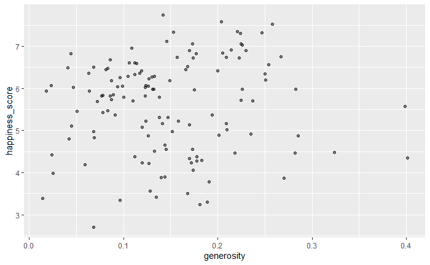

```r
ggplot(dt_happiness, aes(generosity, happiness_score)) +
  geom_point(alpha = 0.5)
```

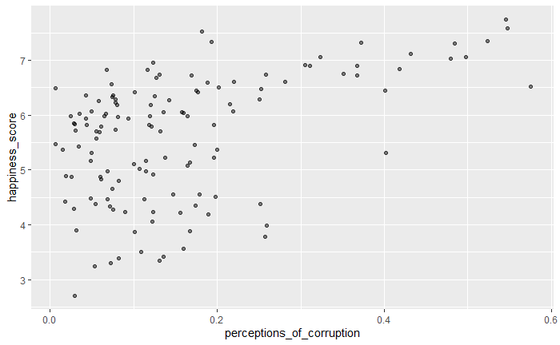

```r
ggplot(dt_happiness, aes(perceptions_of_corruption, happiness_score)) +
  geom_point(alpha = 0.5)
```

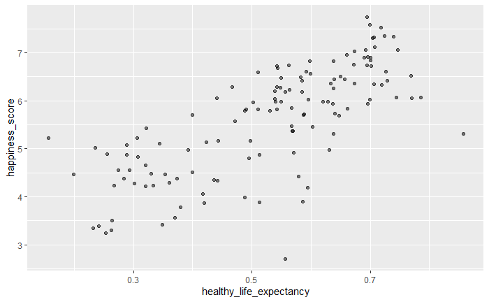

```r
ggplot(dt_happiness, aes(healthy_life_expectancy, happiness_score)) +
  geom_point(alpha = 0.5)
```

We can see, that with a higher gdp the happinnes_score is higher on average. We can clearly say a low gdp_per_capita results in a low happiness_score and a high gdp_per_capita results into a high happiness_score. Nevertheless there is a spread at almost every gdp level. That tells us that the gdp can explain some but not all of the happiness.

In the next step I will visualize the gdp distribution for each region.

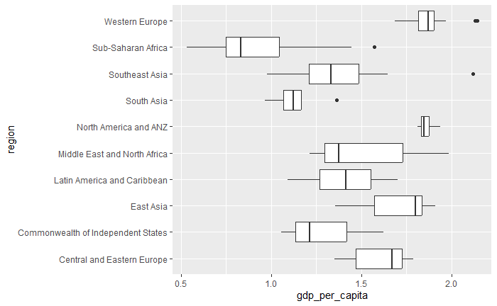

```r
ggplot(dt_happiness, aes(region, gdp_per_capita)) +
  geom_boxplot() +
  coord_flip()
```

We can clearly see that a region occupies a distinct GDP range. The GDP is not distributed randomly.

Next I want to see the distribution of the happiness score for each region.

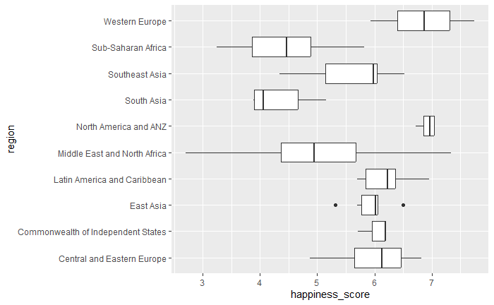

```r
ggplot(dt_happiness, aes(region, happiness_score)) +
  geom_boxplot() +
  coord_flip()
```

We can see major differences between regions, when measuring their happiness score. Western Europe and North America and ANZ achieving the highest score, while Sub-Saharan Africa and South Asia achieving the lowest score. We have smaller boxes such as in North America and ANZ which indicates, that the countries based in the region, have a similar happiness index. Regions with wider boxes, such as countries in the Middle East and North Africa, have a wider distributed happiness score.

# Models 1 & 2

## Linear model

Lets begin to make our model. Our dependend variable is the happiness_score and our input variables are: the gdp_per_capita, the social_support, the healthy_life_expectancy, the freedom_to_make_life_choices, the generosity and the perceptions_of_corruption

```r
lm <- lm(
  happiness_score ~
  +gdp_per_capita
  +social_support
  +healthy_life_expectancy
  +freedom_to_make_life_choices
  +generosity
  +perceptions_of_corruption,
  data = dt_happiness
)
```

```r
lm$coefficients
```

```
                 (Intercept)               gdp_per_capita               social_support
                   1.3936269                    0.6735159                    1.4808085
     healthy_life_expectancy freedom_to_make_life_choices                   generosity
                   0.5330472                    1.7326976                    0.1064673
   perceptions_of_corruption
                   1.1498961
```

```r
summary(lm)
```

```
Call:
lm(formula = happiness_score ~ +gdp_per_capita + social_support +
    healthy_life_expectancy + freedom_to_make_life_choices +
    generosity + perceptions_of_corruption, data = dt_happiness)

Residuals:
     Min       1Q   Median       3Q      Max
-1.62545 -0.22407  0.03474  0.32187  1.06433

Coefficients:
                             Estimate Std. Error t value Pr(>|t|)
(Intercept)                    1.3936     0.2343   5.948 2.61e-08 ***
gdp_per_capita                 0.6735     0.2643   2.548   0.0121 *
social_support                 1.4808     0.2432   6.089 1.34e-08 ***
healthy_life_expectancy        0.5330     0.5775   0.923   0.3578
freedom_to_make_life_choices   1.7327     0.3432   5.049 1.56e-06 ***
generosity                     0.1065     0.6593   0.161   0.8720
perceptions_of_corruption      1.1499     0.4236   2.714   0.0076 **
---
Signif. codes:  0 ‘***’ 0.001 ‘**’ 0.01 ‘*’ 0.05 ‘.’ 0.1 ‘ ’ 1

Residual standard error: 0.5078 on 123 degrees of freedom
Multiple R-squared:  0.8049,    Adjusted R-squared:  0.7953
F-statistic: 84.56 on 6 and 123 DF,  p-value: < 2.2e-16
```

```r
lm_metrics <- calculate_lm_metrics(lm)

lm_metrics$rmse
```

```
[1] 0.4939484
```

```r
lm_metrics$r2
```

```
[1] 0.8048642
```

That means that the linear regression model explains around 80.5% percent of the variance in the response of the variable.

## Tree model

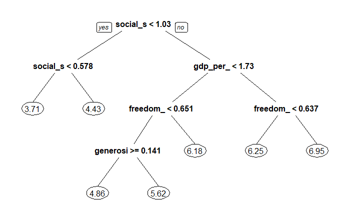

```r
tree <- rpart(
  happiness_score ~
  gdp_per_capita
  +social_support
  +healthy_life_expectancy
  +freedom_to_make_life_choices
  +generosity
  +perceptions_of_corruption,
  data = dt_happiness,
  method="anova"
)

prp(tree, digits = -3)
```

```r
printcp(tree)
```

```
Regression tree:
rpart(formula = happiness_score ~ gdp_per_capita + social_support +
    healthy_life_expectancy + freedom_to_make_life_choices +
    generosity + perceptions_of_corruption, data = dt_happiness,
    method = "anova")

Variables actually used in tree construction:
[1] freedom_to_make_life_choices gdp_per_capita               generosity
[4] social_support

Root node error: 162.54/130 = 1.2503

n= 130

        CP nsplit rel error  xerror     xstd
1 0.616243      0   1.00000 1.01465 0.102870
2 0.117454      1   0.38376 0.42783 0.055331
3 0.049354      2   0.26630 0.30882 0.041844
4 0.020379      3   0.21695 0.28196 0.039280
5 0.018242      4   0.19657 0.29395 0.039619
6 0.018011      5   0.17833 0.29081 0.039844
7 0.010000      6   0.16032 0.31393 0.043921
```

```r
tree
```

```
n= 130

node), split, n, deviance, yval
      * denotes terminal node

 1) root 130 162.543500 5.599815
   2) social_support< 1.027 41  16.650160 4.306537
     4) social_support< 0.5775 7   2.979477 3.713857 *
     5) social_support>=0.5775 34  10.705560 4.428559 *
   3) social_support>=1.027 89  45.727040 6.195596
     6) gdp_per_capita< 1.733 54  18.278200 5.822722
      12) freedom_to_make_life_choices< 0.6505 25   7.465082 5.407600
        24) generosity>=0.141 7   2.126135 4.858857 *
        25) generosity< 0.141 18   2.411404 5.621000 *
      13) freedom_to_make_life_choices>=0.6505 29   2.791023 6.180586 *
     7) gdp_per_capita>=1.733 35   8.357422 6.770886
      14) freedom_to_make_life_choices< 0.6365 9   1.598238 6.248000 *
      15) freedom_to_make_life_choices>=0.6365 26   3.446723 6.951885 *
```

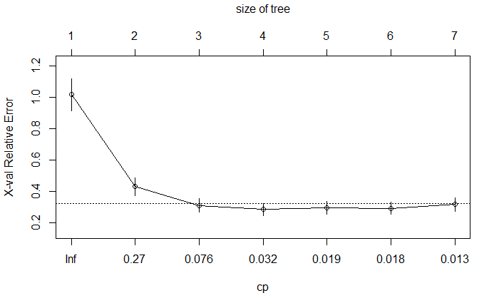

```r
plotcp(tree)
```

```r
tree_metrics <- calculate_tree_metrics(tree, dt_happiness, "happiness_score")

tree_metrics$rmse
```

```
[1] 0.4477169
```

```r
tree_metrics$r2
```

```
[1] 0.8396825
```

That means that the tree regression model explains around 84% percent of the variance in the response of the variable.

## Comparing

Lets compare the rmse values of the tree and the linear model

```r
((lm_metrics$rmse - tree_metrics$rmse)/lm_metrics$rmse) * 100
```

```
[1] 9.359568
```

The regression tree achieves an approximately 9.35% lower RMSE than the linear model, indicating a improvement in predictive accuracy.

```r
(tree_metrics$r2 - lm_metrics$r2) * 100
```

```
[1] 3.481831
```

The regression tree explains 3.5 additional percentage points of variance compared to the linear model

# Feature Engineering

## Feature 1

Lets add the feature as a new column to our table

```r
dt_happiness$log_gdp <- log(dt_happiness$gdp_per_capita)
```

### Linear Model

We will make the gdp as a logarithmic variable

```r
lm1 <- lm(
  happiness_score ~
  gdp_per_capita
  +log_gdp
  +social_support
  +healthy_life_expectancy
  +freedom_to_make_life_choices
  +generosity
  +perceptions_of_corruption,
  data = dt_happiness
)
```

Calculate r2 and rmse of our new model

```r
lm1_metrics <- calculate_lm_metrics(lm1)
```

### Tree Model

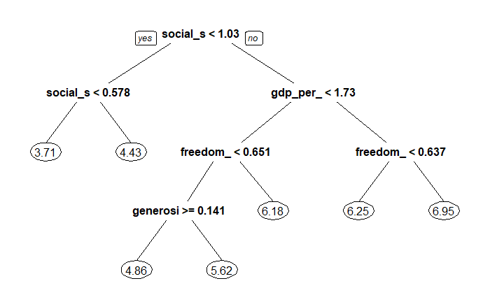

```r
tree1 <- rpart(
  happiness_score ~
  gdp_per_capita
  +log_gdp
  +social_support
  +healthy_life_expectancy
  +freedom_to_make_life_choices
  +generosity
  +perceptions_of_corruption,
  data = dt_happiness,
  method="anova"
)

prp(tree1, digits = -3)
```

```r
tree1
```

```
n= 130

node), split, n, deviance, yval
      * denotes terminal node

 1) root 130 162.543500 5.599815
   2) social_support< 1.027 41  16.650160 4.306537
     4) social_support< 0.5775 7   2.979477 3.713857 *
     5) social_support>=0.5775 34  10.705560 4.428559 *
   3) social_support>=1.027 89  45.727040 6.195596
     6) gdp_per_capita< 1.733 54  18.278200 5.822722
      12) freedom_to_make_life_choices< 0.6505 25   7.465082 5.407600
        24) generosity>=0.141 7   2.126135 4.858857 *
        25) generosity< 0.141 18   2.411404 5.621000 *
      13) freedom_to_make_life_choices>=0.6505 29   2.791023 6.180586 *
     7) gdp_per_capita>=1.733 35   8.357422 6.770886
      14) freedom_to_make_life_choices< 0.6365 9   1.598238 6.248000 *
      15) freedom_to_make_life_choices>=0.6365 26   3.446723 6.951885 *
```

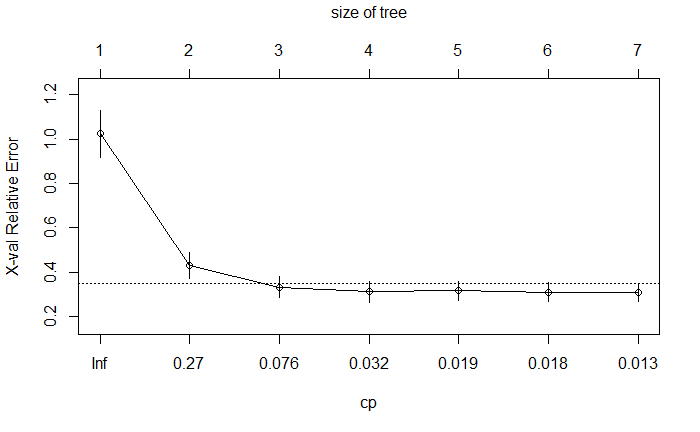

```r
plotcp(tree1)
```

```r
tree1_metrics <- calculate_tree_metrics(tree1, dt_happiness, "happiness_score")
```

## Feature 2

Lets add the feature as a new column to our table

```r
dt_happiness$gdp_x_support <- dt_happiness$gdp_per_capita * dt_happiness$social_support
```

### Linear Model

```r
lm2 <- lm(
  happiness_score ~
  gdp_per_capita
  +gdp_x_support
  +social_support
  +healthy_life_expectancy
  +freedom_to_make_life_choices
  +generosity
  +perceptions_of_corruption,
  data = dt_happiness
)
```

Calculate r2 and rmse of our new model

```r
lm2_metrics <- calculate_lm_metrics(lm2)
```

### Tree Model

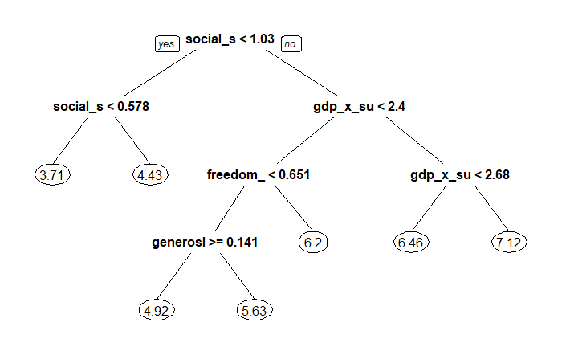

```r
tree2 <- rpart(
  happiness_score ~
  gdp_per_capita
  +gdp_x_support
  +social_support
  +healthy_life_expectancy
  +freedom_to_make_life_choices
  +generosity
  +perceptions_of_corruption,
  data = dt_happiness,
  method="anova"
)

prp(tree2, digits = -3)
```

```r
tree2
```

```
n= 130

node), split, n, deviance, yval
      * denotes terminal node

 1) root 130 162.543500 5.599815
   2) social_support< 1.027 41  16.650160 4.306537
     4) social_support< 0.5775 7   2.979477 3.713857 *
     5) social_support>=0.5775 34  10.705560 4.428559 *
   3) social_support>=1.027 89  45.727040 6.195596
     6) gdp_x_support< 2.404486 55  19.319720 5.826836
      12) freedom_to_make_life_choices< 0.6505 26   7.793198 5.413077
        24) generosity>=0.141 8   2.308992 4.916000 *
        25) generosity< 0.141 18   2.628996 5.634000 *
      13) freedom_to_make_life_choices>=0.6505 29   3.084745 6.197793 *
     7) gdp_x_support>=2.404486 34   6.829726 6.792118
      14) gdp_x_support< 2.683566 17   1.330719 6.459235 *
      15) gdp_x_support>=2.683566 17   1.731444 7.125000 *
```

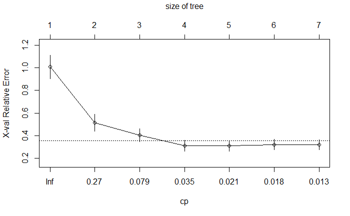

```r
plotcp(tree2)
```

```r
tree2_metrics <- calculate_tree_metrics(tree2, dt_happiness, "happiness_score")
```

# Comparison

```r
dt_feature <- data.table(
  Model = c(
    "Linear Regression",
    "Linear Regression (Feature 1)",
    "Linear Model (Feature 2)",
    "Tree Regression",
    "Tree Regression (Feature 1)",
    "Tree Regression (Feature 2)"
  ),
  rmse = c(
    lm_metrics$rmse,
    lm1_metrics$rmse,
    lm2_metrics$rmse,
    tree_metrics$rmse,
    tree1_metrics$rmse,
    tree2_metrics$rmse
  ),
  r2 = c(
    lm_metrics$r2,
    lm1_metrics$r2,
    lm2_metrics$r2,
    tree_metrics$r2,
    tree1_metrics$r2,
    tree2_metrics$r2
  )
)

setorder(dt_feature, rmse, -r2)



dt_feature[,rmse_rank := frank(rmse, ties.method = "min")][,r2_rank := frank(-r2, ties.method = "min")]
```

```
                           Model      rmse        r2 rmse_rank r2_rank
                          <char>     <num>     <num>     <int>   <int>
1:   Tree Regression (Feature 2) 0.4365065 0.8476104         1       1
2:               Tree Regression 0.4477169 0.8396825         2       2
3:   Tree Regression (Feature 1) 0.4477169 0.8396825         2       2
4:      Linear Model (Feature 2) 0.4808335 0.8150888         4       4
5: Linear Regression (Feature 1) 0.4919962 0.8064036         5       5
6:             Linear Regression 0.4939484 0.8048642         6       6
```

```r
head(dt_feature)
```

| Model | rmse | r2 | rmse_rank | r2_rank |
| --- | --- | --- | --- | --- |
| Tree Regression (Feature 2) | 0.4365065 | 0.8476104 | 1 | 1 |
| Tree Regression | 0.4477169 | 0.8396825 | 2 | 2 |
| Tree Regression (Feature 1) | 0.4477169 | 0.8396825 | 2 | 2 |
| Linear Model (Feature 2) | 0.4808335 | 0.8150888 | 4 | 4 |
| Linear Regression (Feature 1) | 0.4919962 | 0.8064036 | 5 | 5 |
| Linear Regression | 0.4939484 | 0.8048642 | 6 | 6 |

We can see that the Tree regression model with feature 2 gives us the most precise prediction